# **Project 2**, APS1070 Winter 2024

**Anomaly Detection Algorithm using Gaussian Mixture Model**

**Deadline: Feb 27, 11 PM - 13 percent**

**Academic Integrity**

This project is individual - it is to be completed on your own. If you have questions, please post your query in the APS1070 Piazza Q&A forums (the answer might be useful to others!).

Do not share your code with others, or post your work online. Do not submit code that you have not written yourself. Students suspected of plagiarism on a project, midterm or exam will be referred to the department for formal discipline for breaches of the Student Code of Conduct.

Please fill out the following:

- Name: Parsa Youssefpour
- Student Number: 1004749659

### How to submit **(HTML + IPYNB)**

1. Download your notebook: `File -> Download .ipynb`
2. Click on the Files icon on the far left menu of Colab
3. Select & upload your `.ipynb` file you just downloaded, and then obtain its path (right click) (you might need to hit the Refresh button before your file shows up)
1. execute the following in a Colab cell:

   ```
   %%shell
   jupyter nbconvert --to html /PATH/TO/YOUR/NOTEBOOKFILE.ipynb
   ```

2. An HTML version of your notebook will appear in the files, so you can download it.
3. Submit **both** `HTML` and `IPYNB` files on Quercus for grading.

Ref: https://stackoverflow.com/a/64487858

## **Part 1: Getting started [1.5 Marks]**

We are going to work with a Landsat Satellite dataset, consisting of multi-spectral values of pixels in 3x3 neighbourhoods in a satellite image, and the classification associated with the central pixel in each neighbourhood. One frame of Landsat MSS imagery consists of four digital images of the same scene in different spectral bands. Each pixel is a 8-bit binary word, with 0 corresponding to black and 255 to white. The database is a sub-area of a scene, consisting of 82 x 100 pixels. Each line of data corresponds to a 3x3 square neighbourhood of pixels completely contained within the 82x100 sub-area. Each line contains the pixel values in the four spectral bands (converted to ASCII) of each of the 9 pixels in the 3x3 neighbourhood and a label assigned to the central pixel indicating if the image is classified as any types of soil, or a cotton crop. The aim is to predict the class, given the multi-spectral values (`Attribute1`, `Attribute2`, … `Attribute36`). Load the dataset in CSV file using Pandas. The dataset is called `LandsatSatellite.csv`. Print out the first few columns of the dataset.

- How many rows are there? **[0.1]**

  5803
- Which column contains the targets? **[0.1]**

  isanomaly
- What is the meaning of target values? **[0.2]**

  The target value is meant to be used to classify anomalies and typical satellite images

```python
!python3 -m pip install wget
```

```
  Installing build dependencies ... done
  Getting requirements to build wheel ... done
  Preparing metadata (pyproject.toml) ... done
```

```python
import wget

wget.download('https://raw.githubusercontent.com/Sabaae/Dataset/master/LandsatSatellite.csv')
```

```
'LandsatSatellite.csv'
```

```python
import pandas as pd
import numpy as np
import matplotlib.pyplot as plt
import seaborn as sns
from sklearn.model_selection import train_test_split
from sklearn.preprocessing import StandardScaler
import os
```

```python
current_dir = os.getcwd()
dataset = pd.read_csv(os.path.join(current_dir, "LandsatSatellite.csv"))
```

```python
print("Number of rows:" , dataset.shape[0])
print(dataset.head())
```

```
Number of rows: 5803
   Attribute1  Attribute2  Attribute3  Attribute4  Attribute5  Attribute6  \
0        92.0       115.0       120.0        94.0        84.0       102.0
1        84.0       102.0       106.0        79.0        84.0       102.0
2        84.0       102.0       102.0        83.0        80.0       102.0
3        80.0       102.0       102.0        79.0        84.0        94.0
4        84.0        94.0       102.0        79.0        80.0        94.0

   Attribute7  Attribute8  Attribute9  Attribute10  ...  Attribute28  \
0       106.0        79.0        84.0        102.0  ...        104.0
1       102.0        83.0        80.0        102.0  ...        100.0
2       102.0        79.0        84.0         94.0  ...         87.0
3       102.0        79.0        80.0         94.0  ...         79.0
4        98.0        76.0        80.0        102.0  ...         79.0

   Attribute29  Attribute30  Attribute31  Attribute32  Attribute33  \
0         88.0        121.0        128.0        100.0         84.0
1         84.0        107.0        113.0         87.0         84.0
2         84.0         99.0        104.0         79.0         84.0
3         84.0         99.0        104.0         79.0         84.0
4         84.0        103.0        104.0         79.0         79.0

   Attribute34  Attribute35  Attribute36  isanomaly
0        107.0        113.0         87.0        0.0
1         99.0        104.0         79.0        0.0
2         99.0        104.0         79.0        0.0
3        103.0        104.0         79.0        0.0
4        107.0        109.0         87.0        0.0

[5 rows x 37 columns]
```

It's important to know how many examples we have for each class when we work with a new dataset.

- What is the percentage of entries in the dataset for each class? **[0.1]**  
  Class 1: 98.78% Class 2: 1.22%
- Is this data considered balanced or unbalanced? Why is this the case? **[0.1]**  
  No the data is significanlly more data for the fist class than the second class
- Why is balance/imbalance important? How might this class ditribution affect a KNN classifier for example, which we explored in Project 1? **[0.2]**

  The data needs to be balance for the model to be able to learn the features of the both classes properly. If the model were to only predict class 1, it would be able to achieve a very high accuracy, while the model is not working properly.

```python
class_counts = dataset['isanomaly'].value_counts()
print(f"Percentage Class 1: {round(class_counts[0]/dataset.shape[0]*100,2)}% | Percentage Class 1: {round(class_counts[1]/dataset.shape[0]*100,2)}% ")
```

```
Percentage Class 1: 98.78% | Percentage Class 1: 1.22%
```

Next, split the dataset into a training (70%), validation (15%) and testing set (15%). Set the random state to 0. **[0.2]**

Make sure to separate out the column corresponding to the targets.

```python
feature_labels = list(dataset.columns)
feature_labels.remove('isanomaly')
features_df = dataset[feature_labels]
X_train, X_test_val, y_train, y_test_val = train_test_split(features_df, dataset['isanomaly'],test_size=0.3, random_state=0)
X_test, X_val, y_test, y_val = train_test_split(X_test_val, y_test_val,test_size=0.50, random_state=0)
```

Now, let's take a look at the difference in distribution for all variables between typical and anomalous satellite images:

```
Attribute1
Attribute2
Attribute3
Attribute4
Attribute5
Attribute6
Attribute7
Attribute8
Attribute9
Attribute10
Attribute11
Attribute12
Attribute13
Attribute14
Attribute15
Attribute16
Attribute17
Attribute18
Attribute19
Attribute20
Attribute21
Attribute22
Attribute23
Attribute24
Attribute25
Attribute26
Attribute27
Attribute28
Attribute29
Attribute30
Attribute31
Attribute32
Attribute33
Attribute34
Attribute35
Attribute36
```

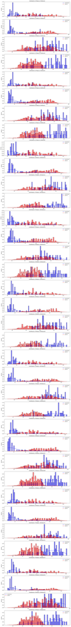

```python
import matplotlib.gridspec as gridspec
features=[f for f in dataset.columns if not 'isanomaly' in f]
nplots=np.size(features)
plt.figure(figsize=(15,4*nplots))
gs = gridspec.GridSpec(nplots,1)
for i, feat in enumerate(features):
    print(feat)
    ax = plt.subplot(gs[i])
    sns.histplot(X_train[feat][y_train==1], stat="density", kde=True, color="blue", bins=50)
    sns.histplot(X_train[feat][y_train==0], stat="density", kde=True, color="red", bins=50)
    ax.legend(['anomalous', 'typical'],loc='best')
    ax.set_xlabel('')
    ax.set_title('Distribution of feature: ' + feat)
```

Explain how these graphs could provide meaningful information about anomaly detection using a gaussian model. **[0.5]**

ANSWER: These graphs show the distribution of data for each feature. By comparing the distributions of the anomalous and typical, which features are best for classification can be determined. The attributes where the distribution (mean and std) of the anomalous and typical data are very different are very helpful in classification as the model can use the difference in distribution to make predictions. While certain features, such as feature 35, in which the two classes have very similar distributions, are less useful for classification.

## **Part 2: Single feature model with one Gaussian distribution: [2.5 Marks]**

We'll start by making a prediction using **a single feature of our dataset at a time**.

**a. Fitting regardless of class:**

1. Fit a single Gaussian distribution on a single feature of **the full training dataset** (both classes) using `sklearn.mixture.GaussianMixture` when `n_components=1`.
2. Compute AUC (Area under the ROC Curve) based on `sklearn.mixture.GaussianMixture.score_samples` on both the full training set and validation set (including both classes).
3. Repeat the above steps for each of the features and present your findings in a table.
4. Find the best 3 features to distinguish anomalous from typical satellite images based on the AUC of the validation set. **[0.2]**
5. Make a prediction based on a model's scores: If the `score_samples` is lower than a threshold, we consider that satellite image as an anomaly. Find an optimal threshold that maximizes the F1 Score of the validation set for each of those 3 features separately. (Do not check every possible value for threshold, come up with a faster way!) Compute F1 score using `sklearn.metrics.f1_score`. **[0.5]**
6. Report the complexity of your method (Big O notation) for determining the optimal threshold.**[0.5]**

**b. Fitting based on class:**

1. Pick 3 features that had the best AUC in Part 2a.
2. Compute AUC and F1 score when you fit a Gaussian **only on typical satellite images** (instead of all the satellite images).
3. Compare your results from parts 2a and 2b (AUC and F1 score) in a table. **[0.8]**
4. Are these results different or similar? Why?**[0.5]**

```python
#Part A
from sklearn.mixture import GaussianMixture
from sklearn.metrics import roc_curve, roc_auc_score, f1_score

gmm = GaussianMixture(n_components=1, random_state=0)
AUC_train = []
AUC_val = []

for feature in feature_labels:
    train_feature = X_train[feature].values.reshape(-1,1)
    val_feature = X_val[feature].values.reshape(-1,1)
    gmm.fit(train_feature)

    train_score = gmm.score_samples(train_feature)
    val_score = gmm.score_samples(val_feature)
    AUC_train.append(roc_auc_score(y_train,-1 * train_score))
    AUC_val.append(roc_auc_score(y_val, -1 * val_score))


AUC_table = {'Feature': feature_labels, 'AUC Train': AUC_train, "AUC VAL": AUC_val}
df_AUC_table = pd.DataFrame(data=AUC_table)
print(df_AUC_table)
```

```
        Feature  AUC Train   AUC VAL
0    Attribute1   0.824249  0.875813
1    Attribute2   0.861819  0.937156
2    Attribute3   0.588497  0.602725
3    Attribute4   0.825337  0.882564
4    Attribute5   0.852065  0.911444
5    Attribute6   0.907774  0.929030
6    Attribute7   0.602368  0.608393
7    Attribute8   0.854314  0.930030
8    Attribute9   0.902215  0.937781
9   Attribute10   0.926950  0.959035
10  Attribute11   0.612423  0.673946
11  Attribute12   0.877487  0.925113
12  Attribute13   0.889488  0.919987
13  Attribute14   0.920105  0.979705
```

[output cut: 22 more lines]

```python
# 3 best feature
top_3_feature = df_AUC_table['AUC VAL'].nlargest(3).index
print(df_AUC_table.loc[top_3_feature])
```

```
        Feature  AUC Train   AUC VAL
17  Attribute18   0.913912  0.999542
21  Attribute22   0.929897  0.999500
19  Attribute20   0.857572  0.997500
```

```python
opt_tr_a = []
f1_a = []

for feature in list(df_AUC_table.loc[top_3_feature]['Feature']):
    train_feature = X_train[feature].values.reshape(-1,1)
    val_feature = X_val[feature].values.reshape(-1,1)
    gmm.fit(train_feature)

    best_tr = 0
    best_f1 = 0
    score = gmm.score_samples(val_feature)
    for tr in score:
        f1 = f1_score(y_val, score < tr)

        if f1 > best_f1:
            best_tr = tr
            best_f1 = f1

    opt_tr_a.append(best_tr)
    f1_a.append(best_f1)

    print(f"{feature} | Optimal Threshold: {round(best_tr,5)}  | F1: {round(best_f1,5)}")
```

```
Attribute18 | Optimal Threshold: -6.50822  | F1: 0.96296
Attribute22 | Optimal Threshold: -6.44383  | F1: 0.93333
Attribute20 | Optimal Threshold: -7.9024  | F1: 0.8
```

ANSWER: The complexity of the a above algorithm for each of the 3 features in O(n) where n is the length of the score array (assuming that the score_samples and f1_score have a complexity of O(1))

```python
#Part B
opt_tr_b = []
f1_b = []
train_auc_b = []
val_auc_b = []

df_typical_train = X_train[y_train == 0]

for feature in list(df_AUC_table.loc[top_3_feature]['Feature']):
    train_feature = df_typical_train[feature].values.reshape(-1,1)
    val_feature = X_val[feature].values.reshape(-1,1)
    gmm.fit(train_feature)

    best_tr = 0
    best_f1 = 0
    train_score = gmm.score_samples(X_train[feature].values.reshape(-1,1))
    val_score = gmm.score_samples(val_feature)
    train_auc = roc_auc_score(y_train,-1 * train_score)
    val_auc = roc_auc_score(y_val, -1 * val_score)

    for tr in val_score:
        f1 = f1_score(y_val, val_score < tr)

        if f1 > best_f1:
            best_tr = tr
            best_f1 = f1

    opt_tr_b.append(best_tr)
    f1_b.append(best_f1)
    train_auc_b.append(train_auc)
    val_auc_b.append(val_auc)

    print(f"{feature} | Optimal Threshold: {round(best_tr,5)} | F1: {round(best_f1,5)}")
    print(f"Train AUC: {round(train_auc,5)} | Val AUC: {round(val_auc,5)}\n")
```

```
Attribute18 | Optimal Threshold: -6.76073 | F1: 0.96296
Train AUC: 0.91471 | Val AUC: 0.99954

Attribute22 | Optimal Threshold: -6.69459 | F1: 0.93333
Train AUC: 0.92953 | Val AUC: 0.9995

Attribute20 | Optimal Threshold: -6.74201 | F1: 0.8
Train AUC: 0.85949 | Val AUC: 0.998
```

```python
#comparing values of part a and b
comp_AB={"Attribute":list(df_AUC_table.loc[top_3_feature]['Feature']), "Optimal Threshold A":opt_tr_a, "Optimal Threshold B":opt_tr_b, "F1 A": f1_a, "F1 B": f1_b, "Train AUC A": list(df_AUC_table.loc[top_3_feature]['AUC Train']), "Train AUC B":train_auc_b, "Val AUC A":list(df_AUC_table.loc[top_3_feature]['AUC VAL']), "Val AUC B":val_auc_b}
table_ab = pd.DataFrame(comp_AB)
display(table_ab)
```

|  | Attribute | Optimal Threshold A | Optimal Threshold B | F1 A | F1 B | Train AUC A | Train AUC B | Val AUC A | Val AUC B |
| --- | --- | --- | --- | --- | --- | --- | --- | --- | --- |
| 0 | Attribute18 | -6.508216 | -6.760732 | 0.962963 | 0.962963 | 0.913912 | 0.914713 | 0.999542 | 0.999542 |
| 1 | Attribute22 | -6.443826 | -6.694586 | 0.933333 | 0.933333 | 0.929897 | 0.929535 | 0.999500 | 0.999500 |
| 2 | Attribute20 | -7.902398 | -6.742015 | 0.800000 | 0.800000 | 0.857572 | 0.859494 | 0.997500 | 0.998000 |

ANSWER:

As expected the the higher the attributes AUC, the higher the F1 score. When comparing the results of part A and B it can be seen that the F1 Scores are the same, with the rest of the metrics being very similar to each other. This can be due to the data being significantly unbalanced.

## **Part 3: Multiple feature model with one Gaussian distribution: [1 Marks]**

This part is similar to Part 2, but we will pick multiple features and **visually** set the number of components.

a. 2D plot:

1. Pick two features (say, f1 and f2).
2. Scatter plot (plt.scatter) those features on a figure (f1 on the x-axis and f2 on the y-axis).
3. Color the data points based on their class (anomalous blue and typical red).
4. Based on your plots, decide how many Gaussian components (`n_components`) you need to fit the data (focus on typical satellite images). Explain. **[0.25]**
5. Fit your Gaussian model on all the data points.
6. Compute AUC on both training and validation sets
7. Pick 3 new pairs of features and repeat steps 2 to 6. **[0.25]**
8. For each pair, find a threshold to maximize your validation set F1 Score.**[0.25]**
9. For each pair, plot a figure similar to step 3 and put a circle around outliers based on your threshold (use the code of the similar figure in the tutorial) **[0.25]**

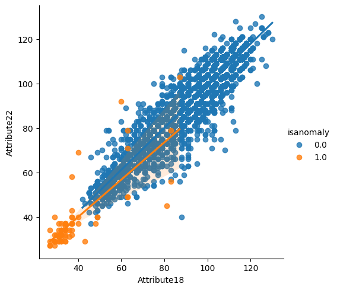

```python
import seaborn
import matplotlib.pyplot as plt

seaborn.lmplot(x="Attribute18",y= "Attribute22", data=dataset, hue="isanomaly", legend=True)
```

ANSWER:

There are two clusters, therefore a n_component of 2 seams appropriate.

```
AUC for Train DATA: 0.9709233717304695
AUC for Val DATA: 0.9862477079513252
Optimal Threshold: -10.46513
Best F1: 0.61905
```

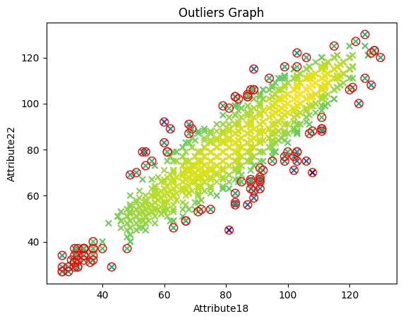

```python
# Using the top two features based on the AUC score
gmm_2 = GaussianMixture(n_components=2, random_state=0)
gmm_2.fit(X_train[['Attribute18','Attribute22']])

train_score = gmm_2.score_samples(X_train[['Attribute18','Attribute22']])
val_score = gmm_2.score_samples(X_val[['Attribute18','Attribute22']])

train_auc = roc_auc_score(y_train,-1 * train_score)
val_auc = roc_auc_score(y_val, -1 * val_score)

best_tr = 0
best_f1 = 0

for tr in val_score:
    f1 = f1_score(y_val, val_score < tr)

    if f1 > best_f1:
        best_tr = tr
        best_f1 = f1

print(f"AUC for Train DATA: {train_auc}  \nAUC for Val DATA: {val_auc}  \nOptimal Threshold: {round(best_tr,5)}  \nBest F1: {round(best_f1,5)}")


plt.scatter(X_train['Attribute18'],X_train['Attribute22'],marker="x",c=train_score,cmap='viridis')
outliers = np.nonzero(train_score<best_tr)[0]
plt.scatter(X_train['Attribute18'].iloc[outliers],X_train['Attribute22'].iloc[outliers],marker="o",facecolor= "none",edgecolor="r",s=70)
plt.xlabel('Attribute18')
plt.ylabel('Attribute22')
plt.title('Outliers Graph')
plt.show()
```

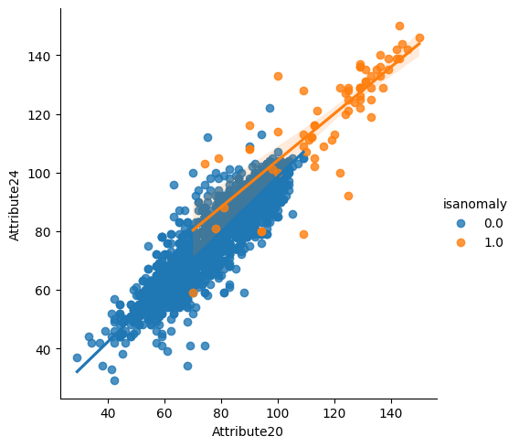

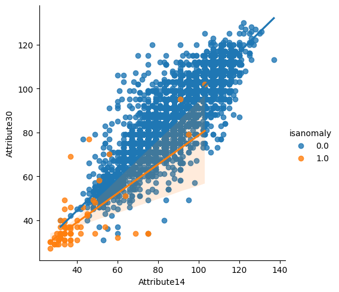

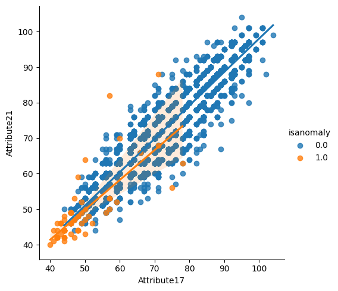

```python
#Using pairs of the top 6 feature (after the top 2, since they were used in the previous step)
part_3_features = list(df_AUC_table.loc[df_AUC_table['AUC VAL'].nlargest(8).index]['Feature'])[2:]

for i in range(0,len(part_3_features),2):
    seaborn.lmplot(x=part_3_features[i],y= part_3_features[i+1], data=dataset, hue="isanomaly", legend=True)
```

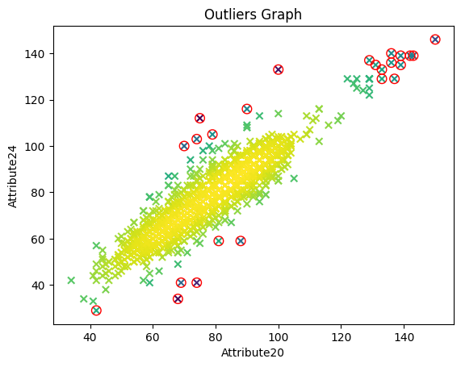

```
Features: Attribute20 and Attribute24
AUC for Train DATA: 0.96735
AUC for Val DATA: 0.99342
Optimal Threshold: -16.58705
Best F1: 0.76923
----------------------------
```

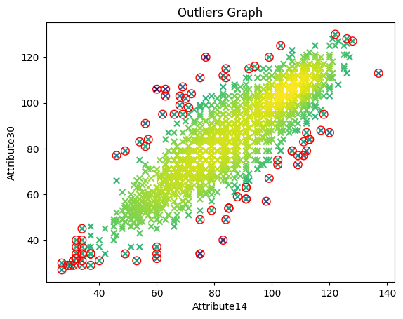

```
Features: Attribute14 and Attribute30
AUC for Train DATA: 0.94945
AUC for Val DATA: 0.97866
Optimal Threshold: -11.35589
Best F1: 0.5641
----------------------------
```

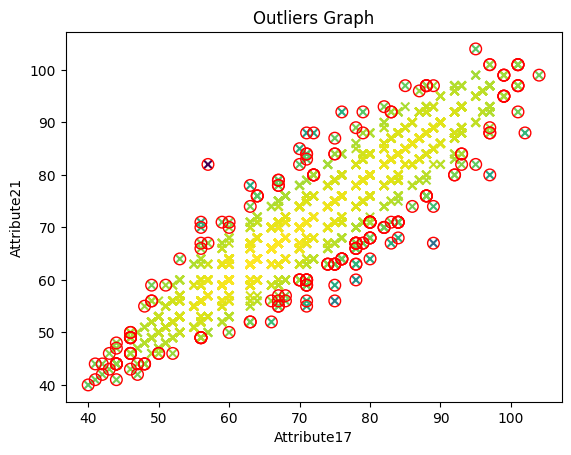

```
Features: Attribute17 and Attribute21
AUC for Train DATA: 0.92183
AUC for Val DATA: 0.97137
Optimal Threshold: -8.5102
Best F1: 0.41379
----------------------------
```

```python
#Using pairs of the top 6 feature (after the top 2, since they were used in the previous step)

for i in range(0,len(part_3_features),2):

    selected_features = [part_3_features[i],part_3_features[i+1]]
    gmm_2.fit(X_train[selected_features])

    train_score = gmm_2.score_samples(X_train[selected_features])
    val_score = gmm_2.score_samples(X_val[selected_features])

    train_auc = roc_auc_score(y_train,-1 * train_score)
    val_auc = roc_auc_score(y_val, -1 * val_score)

    best_tr = 0
    best_f1 = 0

    for tr in val_score:
        f1 = f1_score(y_val, val_score < tr)

        if f1 > best_f1:
            best_tr = tr
            best_f1 = f1

    plt.scatter(X_train[part_3_features[i]],X_train[part_3_features[i+1]],marker="x",c=train_score,cmap='viridis')
    outliers = np.nonzero(train_score<best_tr)[0]
    plt.scatter(X_train[part_3_features[i]].iloc[outliers],X_train[part_3_features[i+1]].iloc[outliers],marker="o",facecolor= "none",edgecolor="r",s=70)
    plt.xlabel(part_3_features[i])
    plt.ylabel(part_3_features[i+1])
    plt.title('Outliers Graph')
    plt.show()

    print(f"Features: {part_3_features[i]} and {part_3_features[i+1]} \nAUC for Train DATA: {round(train_auc,5)}  \nAUC for Val DATA: {round(val_auc,5)}  \nOptimal Threshold: {round(best_tr,5)}  \nBest F1: {round(best_f1,5)}")
    print("----------------------------")
```

## **Part 4: Single feature model with two Gaussian distributions. [2 Marks]**

Now we will use two different distributions for anomalous and typical satellite images.

1. Fit a Gaussian distribution ($G_1$) on a feature of **typical satellite images** using `sklearn.mixture.GaussianMixture` when `n_components=1`. **[0.25]**
2. Fit another Gaussian distribution ($G_2$) on the same feature but for **anomalous satellite images** using `sklearn.mixture.GaussianMixture` when `n_components=1`. **[0.25]**
3. Compute the score samples ($S$) for both $G_1$ and $G_2$ on the **validation set** to get $S_1$ and $S_2$, respectively. **[0.25]**
4. Find an optimal $c$ (a real number) that maximizes validation set F1 Score for a model such that if $S_1 < c \times S_2$, the image is classified as an anomaly. For example, if $c=1$ we could say that if $S_2$ is greater than $S_1$, ($S_1$<$S_2$) then the image is an anomaly (the image belongs to the $G_2$ distribution which represents anomalous satellite images). For start consider $c$ in $[0,10]$ with steps of 0.1, you can change this window in your experiments if needed. **[0.25]**
5. Repeat the steps above for all the features. What is the best F1 Score that you get for training and validation? Which feature and what c? **[1]**

```python
G1 = GaussianMixture(n_components=1, random_state=0)
typical_train = X_train[y_train == 0]

G2 = GaussianMixture(n_components=1, random_state=0)
anomalous_train = X_train[y_train == 1]

best_f1 = 0

for feature in feature_labels:
    G1.fit(typical_train[feature].values.reshape(-1,1))
    S1 = G1.score_samples(X_val[feature].values.reshape(-1,1))
    S1_train = G1.score_samples(X_train[feature].values.reshape(-1,1))

    G2.fit(anomalous_train[feature].values.reshape(-1,1))
    S2 = G2.score_samples(X_val[feature].values.reshape(-1,1))
    S2_train = G2.score_samples(X_train[feature].values.reshape(-1,1))

    best_f1_val = 0
    best_f1_train = 0
    optimal_c =0
    for c in range(0,101):
        c=c/10
        f1_val = f1_score(y_val, S1 < c*S2)
        f1_train = f1_score(y_train, S1_train < c*S2_train)

        if f1_val > best_f1_val:
            best_f1_val = f1_val
            optimal_c = c

        if f1_train > best_f1_train:
            best_f1_train = f1_train

    if best_f1_val > best_f1:
        best_f1 = best_f1_val
        best_train_f1 = best_f1_train
        best_c = optimal_c
        attribute = feature

    print(f"feature: {feature} \nOptimal c: {optimal_c} \nBest Validation F1 score: {best_f1_val} \nBest Train F1 score: {best_f1_train} \n")

print("------------------")
print("Best F1 & Features")
print(f"Best Attribute: {attribute} \nc: {best_c} \nVal F1: {best_f1} \nTrain F1: {best_train_f1}")
```

```
feature: Attribute1
Optimal c: 1.6
Best Validation F1 score: 0.6896551724137931
Best Train F1 score: 0.5333333333333333

feature: Attribute2
Optimal c: 1.8
Best Validation F1 score: 0.8461538461538461
Best Train F1 score: 0.7407407407407407

feature: Attribute3
Optimal c: 1.3
Best Validation F1 score: 0.2
Best Train F1 score: 0.13114754098360656

feature: Attribute4
Optimal c: 1.3
Best Validation F1 score: 0.7692307692307693
Best Train F1 score: 0.7228915662650602

feature: Attribute5
Optimal c: 1.7
Best Validation F1 score: 0.6956521739130435
Best Train F1 score: 0.6835443037974683

feature: Attribute6
Optimal c: 2.0
Best Validation F1 score: 0.9285714285714286
Best Train F1 score: 0.7901234567901234

feature: Attribute7
Optimal c: 1.3
Best Validation F1 score: 0.18604651162790697
Best Train F1 score: 0.12716763005780346

feature: Attribute8
Optimal c: 1.7
Best Validation F1 score: 0.8461538461538461
Best Train F1 score: 0.7469879518072289

```

[output cut: 131 more lines]

```
Optimal c: 1.3
Best Validation F1 score: 0.11764705882352941
Best Train F1 score: 0.11320754716981132

feature: Attribute36
Optimal c: 1.7
Best Validation F1 score: 0.8148148148148148
Best Train F1 score: 0.7441860465116279

------------------
Best F1 & Features
Best Attribute: Attribute20
c: 1.4
Val F1: 1.0
Train F1: 0.8148148148148148
```

## **Part 5: Multivariate and Mixture of Gaussians Distribution [4 Marks]**

We now want to build an outlier detection model that performs well in terms of F1 score. To design your model, you can benefit from:

- No restrictions on the number of features - use as few or as many as you want! (multivariate).
- To fit your model, you can take advantage of the Gaussian mixture model, where you can set the number of components [help](https://scikit-learn.org/stable/modules/generated/sklearn.mixture.GaussianMixture.html).
- You can choose to fit your Gaussians on typical satellite images or to both classes.

It is up to you how to design your model. Try at least 10 different models and report the AUC for both training and validation sets (if applicable) and the best F1 score for both training and validation sets for each model. What kind of model works better? How many features are best (and which ones)? How many Gaussians? How many components? Summarize your findings with tables or plots. **[4]**

**HINT !**

You might want to try a two-gaussian model, multiple features, a single component for the typical satellite images, and multiple components for anomalous ones! Why does it make sense to have multiple components for anomalous satellite images?

```python
def evaluate_model(model, train_feature, val_feature, train_target, val_traget):

    p_train = model.score_samples(train_feature)
    p_val = model.score_samples(val_feature)

    max_train_f1 = 0
    max_val_f1 = 0
    best_tr = 0

    for tr in p_train:
        f1_val = f1_score(val_traget, p_val < tr)
        f1_train = f1_score(train_target, p_train < tr)

        if f1_val > max_train_f1:
            max_train_f1 = f1_val


        if f1_train > max_val_f1:
            best_tr = tr
            max_val_f1 = f1_train

    auc_train = roc_auc_score(train_target,-1 * p_train)
    auc_val = roc_auc_score(val_traget, -1 * p_val)

    print(f"Train AUC: {round(auc_train,5)} | Val AUC: {round(auc_val,5)} \nMax Train F1: {round(max_train_f1,5)} | Max Val F1: {round(max_val_f1,5)}")

    return best_tr, max_train_f1, max_val_f1, auc_train, auc_val
```

```python
# Model 1: Train on the entire dataset
GMM_1 = GaussianMixture(n_components=1, random_state=0)
GMM_1.fit(X_train)
result_1 = evaluate_model(GMM_1, X_train, X_val, y_train, y_val)
```

```
Train AUC: 0.98583 | Val AUC: 0.98816
Max Train F1: 0.5641 | Max Val F1: 0.41791
```

```python
# Model 2: same as before with 2 components
GMM_2 = GaussianMixture(n_components=2, random_state=0)
GMM_2.fit(X_train)
result_2 = evaluate_model(GMM_2, X_train, X_val, y_train, y_val)
```

```
Train AUC: 0.94522 | Val AUC: 0.94532
Max Train F1: 0.32258 | Max Val F1: 0.25
```

```python
# Model 3: same as before with 3 components
GMM_3 = GaussianMixture(n_components=3, random_state=0)
GMM_3.fit(X_train)
result_3 = evaluate_model(GMM_3, X_train, X_val, y_train, y_val)
```

```
Train AUC: 0.94976 | Val AUC: 0.94624
Max Train F1: 0.34483 | Max Val F1: 0.26415
```

```python
# Model 4: only training on the top feature with 1 component
GMM_4 = GaussianMixture(n_components=1, random_state=0)

top_feature = df_AUC_table['AUC VAL'].nlargest(1).index
train_data = X_train[list(df_AUC_table.loc[top_feature]['Feature'])]
val_data = X_val[list(df_AUC_table.loc[top_feature]['Feature'])]

GMM_4.fit(train_data)
result_4 = evaluate_model(GMM_4, train_data, val_data, y_train, y_val)
```

```
Train AUC: 0.91391 | Val AUC: 0.99954
Max Train F1: 0.96296 | Max Val F1: 0.85366
```

```python
# Model 5: only training on the top feature with 2 component
GMM_5 = GaussianMixture(n_components=2, random_state=0)

top_feature = df_AUC_table['AUC VAL'].nlargest(1).index
train_data = X_train[list(df_AUC_table.loc[top_feature]['Feature'])]
val_data = X_val[list(df_AUC_table.loc[top_feature]['Feature'])]

GMM_5.fit(train_data)
result_5 = evaluate_model(GMM_5, train_data, val_data, y_train, y_val)
```

```
Train AUC: 0.95058 | Val AUC: 0.99929
Max Train F1: 0.96296 | Max Val F1: 0.77273
```

```python
# Model 6: only training on the top feature with 3 component
GMM_6 = GaussianMixture(n_components=3, random_state=0)

top_feature = df_AUC_table['AUC VAL'].nlargest(1).index
train_data = X_train[list(df_AUC_table.loc[top_feature]['Feature'])]
val_data = X_val[list(df_AUC_table.loc[top_feature]['Feature'])]

GMM_6.fit(train_data)
result_6 = evaluate_model(GMM_6, train_data, val_data, y_train, y_val)
```

```
Train AUC: 0.93403 | Val AUC: 0.99837
Max Train F1: 0.89655 | Max Val F1: 0.74725
```

```python
# Model 7: only training on the top 2 feature with 1 component
GMM_7 = GaussianMixture(n_components=1, random_state=0)

top_feature = df_AUC_table['AUC VAL'].nlargest(2).index
train_data = X_train[list(df_AUC_table.loc[top_feature]['Feature'])]
val_data = X_val[list(df_AUC_table.loc[top_feature]['Feature'])]

GMM_7.fit(train_data)
result_7 = evaluate_model(GMM_7, train_data, val_data, y_train, y_val)
```

```
Train AUC: 0.96494 | Val AUC: 0.98325
Max Train F1: 0.6087 | Max Val F1: 0.48235
```

```python
# Model 8: only training on the top 3 feature with 1 component
GMM_8 = GaussianMixture(n_components=1, random_state=0)

top_feature = df_AUC_table['AUC VAL'].nlargest(3).index
train_data = X_train[list(df_AUC_table.loc[top_feature]['Feature'])]
val_data = X_val[list(df_AUC_table.loc[top_feature]['Feature'])]

GMM_8.fit(train_data)
result_8 = evaluate_model(GMM_8, train_data, val_data, y_train, y_val)
```

```
Train AUC: 0.97467 | Val AUC: 0.99917
Max Train F1: 0.96552 | Max Val F1: 0.88095
```

```python
# Model 9: only training on the top 5 feature with 1 component
GMM_9 = GaussianMixture(n_components=1, random_state=0)

top_feature = df_AUC_table['AUC VAL'].nlargest(5).index
train_data = X_train[list(df_AUC_table.loc[top_feature]['Feature'])]
val_data = X_val[list(df_AUC_table.loc[top_feature]['Feature'])]

GMM_9.fit(train_data)
result_9 = evaluate_model(GMM_9, train_data, val_data, y_train, y_val)
```

```
Train AUC: 0.99296 | Val AUC: 0.99742
Max Train F1: 0.875 | Max Val F1: 0.82828
```

```python
# Model 10: only training on the top 10 feature with 1 component
GMM_10 = GaussianMixture(n_components=1, random_state=0)

top_feature = df_AUC_table['AUC VAL'].nlargest(10).index
train_data = X_train[list(df_AUC_table.loc[top_feature]['Feature'])]
val_data = X_val[list(df_AUC_table.loc[top_feature]['Feature'])]

GMM_10.fit(train_data)
result_10 = evaluate_model(GMM_10, train_data, val_data, y_train, y_val)
```

```
Train AUC: 0.99336 | Val AUC: 0.99583
Max Train F1: 0.8 | Max Val F1: 0.73118
```

```python
# Model 11: only training on the top 1 typical feature with 1 component
GMM_11 = GaussianMixture(n_components=1, random_state=0)
top_feature = df_AUC_table['AUC VAL'].nlargest(1).index

typical_train = X_train[y_train == 0]
training_data = typical_train[list(df_AUC_table.loc[top_feature]['Feature'])]

train_data = X_train[list(df_AUC_table.loc[top_feature]['Feature'])]
val_data = X_val[list(df_AUC_table.loc[top_feature]['Feature'])]

GMM_11.fit(training_data)
result_11 = evaluate_model(GMM_11, train_data, val_data, y_train, y_val)
```

```
Train AUC: 0.91471 | Val AUC: 0.99954
Max Train F1: 0.96296 | Max Val F1: 0.85366
```

```python
# Model 12: only training on the top 3 typical feature with 1 component
GMM_12 = GaussianMixture(n_components=1, random_state=0)
top_feature = df_AUC_table['AUC VAL'].nlargest(3).index

typical_train = X_train[y_train == 0]
training_data = typical_train[list(df_AUC_table.loc[top_feature]['Feature'])]

train_data = X_train[list(df_AUC_table.loc[top_feature]['Feature'])]
val_data = X_val[list(df_AUC_table.loc[top_feature]['Feature'])]

GMM_12.fit(training_data)
result_12 = evaluate_model(GMM_12, train_data, val_data, y_train, y_val)
```

```
Train AUC: 0.97585 | Val AUC: 0.99992
Max Train F1: 0.96552 | Max Val F1: 0.90698
```

```python
# Model 13: only training on the top 5 typical feature with 1 component
GMM_13 = GaussianMixture(n_components=1, random_state=0)
top_feature = df_AUC_table['AUC VAL'].nlargest(5).index

typical_train = X_train[y_train == 0]
training_data = typical_train[list(df_AUC_table.loc[top_feature]['Feature'])]

train_data = X_train[list(df_AUC_table.loc[top_feature]['Feature'])]
val_data = X_val[list(df_AUC_table.loc[top_feature]['Feature'])]

GMM_13.fit(training_data)
result_13 = evaluate_model(GMM_13, train_data, val_data, y_train, y_val)
```

```
Train AUC: 0.99402 | Val AUC: 0.99867
Max Train F1: 0.93333 | Max Val F1: 0.90323
```

```python
# Model 14: only training on the top 3 anamolous feature with 1 component
GMM_14 = GaussianMixture(n_components=1, random_state=0)
top_feature = df_AUC_table['AUC VAL'].nlargest(3).index

typical_train = X_train[y_train == 1]
training_data = typical_train[list(df_AUC_table.loc[top_feature]['Feature'])]

train_data = X_train[list(df_AUC_table.loc[top_feature]['Feature'])]
val_data = X_val[list(df_AUC_table.loc[top_feature]['Feature'])]

GMM_14.fit(training_data)
result_14 = evaluate_model(GMM_14, train_data, val_data, y_train, y_val)
```

```
Train AUC: 0.05839 | Val AUC: 0.00425
Max Train F1: 0.03164 | Max Val F1: 0.02191
```

## **Part 6: Evaluating performance on test set: [1 Mark]**

**Which model worked better?** Pick your best model among all models and apply it to your test set. Report the F1 Score, Precision and Recall on the test set. **[1]**

```python
#Model 12 with the highest Max validation only training on the top 3 typical feature with 1 component
from sklearn.metrics import precision_score, recall_score

top_feature = df_AUC_table['AUC VAL'].nlargest(3).index
test_data = X_test[list(df_AUC_table.loc[top_feature]['Feature'])]


p_test = GMM_12.score_samples(test_data)

best_tr = result_12[0]
max_f1 = f1_score(y_test, p_test < best_tr)

recall = recall_score(y_test, p_test < best_tr)
percision = precision_score(y_test, p_test < best_tr)

print(f"Max F1 score: {round(max_f1,5)} \nRecall: {round(recall,5)} \nPercision: {round(percision,5)}")
```

```
Max F1 score: 0.95652
Recall: 1.0
Percision: 0.91667
```

## **Part 7: Is Gaussian the only useful distribution? [1 Mark]**

Search for other distributions that could be used to model the data. How popular are they? Is there a specific situation where a distribution works better? How can we find a suitable distribution to model our data? Do not forget to include your references.

### Bernoulli Distribution

A bernoulli distribution is used to model situations that have only two outcomes (Binary). Similar to the data that we have in this project. Unlike, gaussian distribution that works with continious data, Bernoulli distribution works with binary discrete data. Which makes this type of distribution unsuitable for this task. [1]

### Binomial Distribution

Bionomial distribution is very similar to the Bernoulli distribution, however, Bionomial looks at multiple events, while Bernoulli only looks at one event. Bionomial distribution also works with bianry discrete data, making it unsuitable for this problem. [1]

### Exponential Distribution

Exponential distribution similar to Gaussian distribution works with continious data. Unlike Gaussian distribution which is shaped like a bell and symetrical, Exponential distribution is unsymetrical and skewed to one side. The Exponential distribution is commonly used to model the time until a specific event. [2]

### Piosson distribution

Poisson is used for modeling the number of events in fixed intervals with a known average rate.The Poisson distribution is discrete, modeling count-based data. In a Poisson distribution, the mean and variance are equal, unlike Gaussian. [2]

### How to find suitable distribution

- Check is the data is discrete or continuous
- Graph the data and check the shape of the distribution, see which distribution fits the data.
- Understand what each of the distributions is used for
- Use a goodness fit test such as Kolmogorov-Smirnov test, the Anderson-Darling test, or the chi-squared test. [3]

### Refrences

[1] M. Raji, “The Bernoulli and Binomial Distributions - Analytics Vidhya - Medium,” Medium, Jan. 24, 2020. https://medium.com/analytics-vidhya/the-bernoulli-and-binomial-distributions-5d6247d48c6a#:~:text=A%20common%20example%20of%20a,for%20example%2C%20a%20coin%20toss. (accessed Feb. 28, 2024).

[2] Y. WONG, “Poisson Distribution & Exponential Distribution - Statistics Memoirs - Medium,” Medium, Jul. 23, 2023. https://medium.com/statistics-memoirs/poisson-distribution-exponential-distribution-225efc634a10 (accessed Feb. 28, 2024). ‌ [3] Salman Sigari, “Discovering the Best-fit Probability Distribution for Your Data,” Medium, Apr. 09, 2023. https://medium.com/@sigari.salman/discovering-the-best-fit-probability-distribution-for-your-data-a14c0e8d762#:~:text=To%20determine%20which%20distribution%20is,and%20the%20chi%2Dsquared%20test. (accessed Feb. 28, 2024). ‌